# Fiddler crabs and Bergmann’s rule

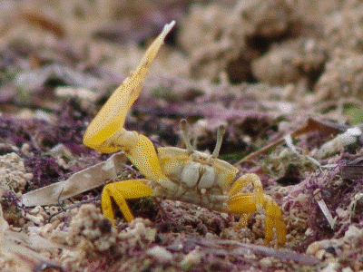

Yellow fiddler crab waving it’s large claw. From Wikipedia.

## Setup:

- Partner up, then decide who is Partner 1 & who is Partner 2 for this activity
- **You should be working together on all of this activity, even though it is split up into “Partner 1” and “Partner 2” sections**

### Partner 1:

- Create a new version-controlled R Project named `fiddler-crab-sizes`
- In a new Quarto document, attach the `lterdatasampler` package
- Read through the documentation for the `pie_crab` data sample, and spend ~5 minutes talking with your partner about the data contains, the shape, variables, and why it was collected. See more information and examples with the data [here](https://lter.github.io/lterdatasampler/articles/pie_crab_vignette.html).
- Save your document
- Push your changes back to GitHub (you don’t need to work in a branch for this step – push straight to `main`)
- Add your partner as a collaborator to the repo

### Partner 2:

- Accept the invitation to collaborate (check your email) & clone the repo
- Create a NEW BRANCH to work in
- In the Quarto doc, create an exploratory (unfinalized) plot of fiddler crab carapace widths observed at the different latitudes
- Push your updates
- Submit a Pull Request through GitHub

### Partner 1:

- Merge in the Pull Request
- Pull changes into `main`
- Switch over into a NEW BRANCH
- **Finalize the figure**. Add a figure caption using `#| fig-cap: "this is my caption"` in the code chunk where the graph is created. Update code chunk options (hint: `execute:` in YAML) so that only your finalized graph and figure caption show up in your knitted report (i.e., no code should show up)
- To your document, add an unfinalized summary table containing the mean, standard deviation, and sample size of fiddler crab carapace widths by site (tip: use `round(mean(), 2)` to round a value to 2 decimal places)
- Push your changes
- Submit a Pull Request in GitHub

### Partner 2:

- Merge in the Pull Request
- Go back to your `main` branch locally, and pull down changes
- Create and checkout a NEW BRANCH
- **Finalize the summary table** a bit so that it looks more polished when rendered, including with updated column names (including units as relevant).
- Push your updates, submit a PR on GitHub

### Partner 1:

- Merge in the PR
- Switch over to your `main` branch locally, pull in changes
- Create and checkout a NEW BRANCH
- Work with your partner to write a short introduction to the figures in your knitted document (e.g. so that if it were shared as a short blog post, someone would understand what they were looking at)
- Add any necessary citations for the data at the end of the document
- Push your changes and submit a PR on GitHub

### Partner 2:

- Merge in the PR

### Both partners:

- Move back over into your `main` local branch
- Pull down changes